# Project 1

Muhammad Ahsan

## Cardio Fitness Project

### 1. Project Objective

The objective of the report is to explore the cardio data set (âCardioGoodFitnessâ) in R and generate insights about the data set. This exploration report will consists of the following:

1. Importing the dataset in R
2. Understanding the structure of dataset
3. Graphical exploration
4. Descriptive statistics
5. Insights from the dataset

### 2. Assumptions

we assume data has normally distribution its mean the graph of the data has a bell curve or skewed.data is independent and it has linear relationship.we will do the further analysis to prove our assumstion.

### 3. Exploratory Data Analysis â Step by step approach

A Typical Data exploration activity consists of the following steps:

#### 3.1 Environment Set up and Data Import

#### Required Libraries

```r
##library(readr)
library(ggplot2)
library(gridExtra)
library(corrplot)
library(scales)
```

##### Setting up working Directory and importing the Dataset

In this chunk we set the working directory and importing the dataset for analysis and we convert the dataset in Data Frames

```r
setwd("F:/DSBA")
cardio_data <- read.csv("CardioGoodFitness.csv")
cardio_data <- data.frame(cardio_data)
```

#### 3.2 Variable Identification

####dimention of the dataset

```r
dim(cardio_data)
```

```
## [1] 180   9
```

This data set has 180 observation and 9 veriables/columns.

####Columns of the dataset

```r
names(cardio_data)
```

```
## [1] "Product"       "Age"           "Gender"        "Education"
## [5] "MaritalStatus" "Usage"         "Fitness"       "Income"
## [9] "Miles"
```

####Structure of the dataset

```r
str(cardio_data)
```

```
## 'data.frame':    180 obs. of  9 variables:
##  $ Product      : Factor w/ 3 levels "TM195","TM498",..: 1 1 1 1 1 1 1 1 1 1 ...
##  $ Age          : int  18 19 19 19 20 20 21 21 21 21 ...
##  $ Gender       : Factor w/ 2 levels "Female","Male": 2 2 1 2 2 1 1 2 2 1 ...
##  $ Education    : int  14 15 14 12 13 14 14 13 15 15 ...
##  $ MaritalStatus: Factor w/ 2 levels "Partnered","Single": 2 2 1 2 1 1 1 2 2 1 ...
##  $ Usage        : int  3 2 4 3 4 3 3 3 5 2 ...
##  $ Fitness      : int  4 3 3 3 2 3 3 3 4 3 ...
##  $ Income       : int  29562 31836 30699 32973 35247 32973 35247 32973 35247 37521 ...
##  $ Miles        : int  112 75 66 85 47 66 75 85 141 85 ...
```

```r
head(cardio_data)
```

|  | Product | Age | Gender | Education | MaritalStatus | Usage | Fitness | Income | Miles |
| --- | --- | --- | --- | --- | --- | --- | --- | --- | --- |
| 1 | TM195 | 18 | Male | 14 | Single | 3 | 4 | 29562 | 112 |
| 2 | TM195 | 19 | Male | 15 | Single | 2 | 3 | 31836 | 75 |
| 3 | TM195 | 19 | Female | 14 | Partnered | 4 | 3 | 30699 | 66 |
| 4 | TM195 | 19 | Male | 12 | Single | 3 | 3 | 32973 | 85 |
| 5 | TM195 | 20 | Male | 13 | Partnered | 4 | 2 | 35247 | 47 |
| 6 | TM195 | 20 | Female | 14 | Partnered | 3 | 3 | 32973 | 66 |

```r
tail(cardio_data)
```

|  | Product | Age | Gender | Education | MaritalStatus | Usage | Fitness | Income | Miles |
| --- | --- | --- | --- | --- | --- | --- | --- | --- | --- |
| 175 | TM798 | 38 | Male | 18 | Partnered | 5 | 5 | 104581 | 150 |
| 176 | TM798 | 40 | Male | 21 | Single | 6 | 5 | 83416 | 200 |
| 177 | TM798 | 42 | Male | 18 | Single | 5 | 4 | 89641 | 200 |
| 178 | TM798 | 45 | Male | 16 | Single | 5 | 5 | 90886 | 160 |
| 179 | TM798 | 47 | Male | 18 | Partnered | 4 | 5 | 104581 | 120 |
| 180 | TM798 | 48 | Male | 18 | Partnered | 4 | 5 | 95508 | 180 |

####Convertion of some columns datatype cracter to factor

```r
cardio_data$Product <- as.factor(cardio_data$Product)
cardio_data$Gender <- as.factor(cardio_data$Gender)
cardio_data$MaritalStatus <- as.factor(cardio_data$MaritalStatus)
cardio_data$Education <- as.factor(cardio_data$Education)
```

####Summary of the data

```r
#Statisticl Summary of Dataset
summary(cardio_data)
```

```
##   Product        Age           Gender      Education    MaritalStatus
##  TM195:80   Min.   :18.00   Female: 76   16     :85   Partnered:107
##  TM498:60   1st Qu.:24.00   Male  :104   14     :55   Single   : 73
##  TM798:40   Median :26.00                18     :23
##             Mean   :28.79                13     : 5
##             3rd Qu.:33.00                15     : 5
##             Max.   :50.00                12     : 3
##                                          (Other): 4
##      Usage          Fitness          Income           Miles
##  Min.   :2.000   Min.   :1.000   Min.   : 29562   Min.   : 21.0
##  1st Qu.:3.000   1st Qu.:3.000   1st Qu.: 44059   1st Qu.: 66.0
##  Median :3.000   Median :3.000   Median : 50597   Median : 94.0
##  Mean   :3.456   Mean   :3.311   Mean   : 53720   Mean   :103.2
##  3rd Qu.:4.000   3rd Qu.:4.000   3rd Qu.: 58668   3rd Qu.:114.8
##  Max.   :7.000   Max.   :5.000   Max.   :104581   Max.   :360.0
##
```

statistical summary tell us the minimum,first qrartile,median, third quartile and maximum value of the dataset.

### 3.3 Univariate Analysis

Univerable analysis is using for single or uni veriable of the dataset we also check how veriable is distributed.

####Products summary and plot:

```r
#Statisticl Summary of Product
summary(cardio_data$Product)
```

```
## TM195 TM498 TM798
##    80    60    40
```

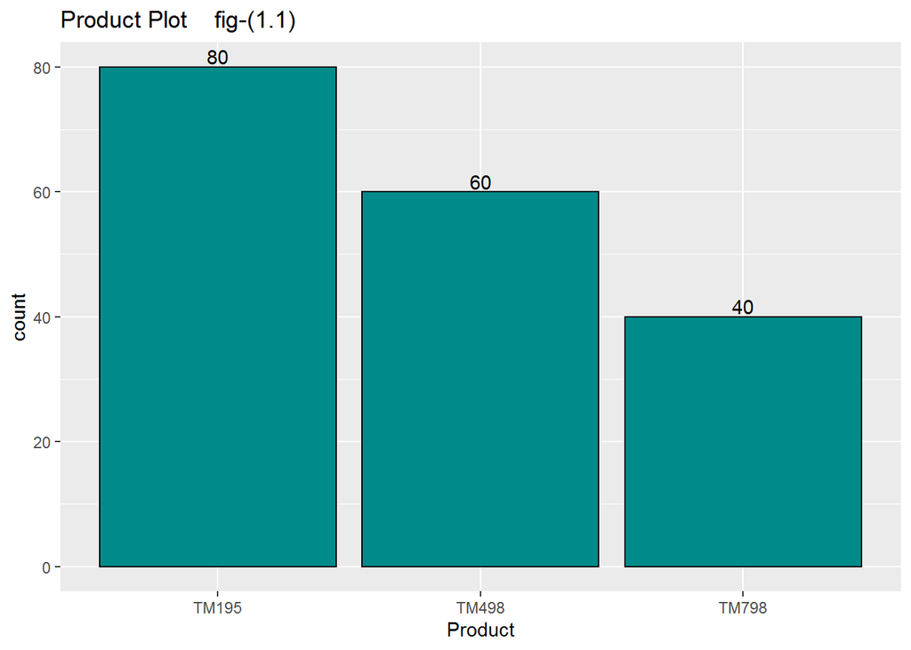

```r
#product plot
p<- ggplot(data = cardio_data, aes(x = Product)) +
  geom_bar(color="black" ,fill="darkcyan") +
  theme_grey() + ggtitle("Product Plot    fig-(1.1)")+xlab("Product")+
  geom_text(stat = 'count',aes(label =..count.., vjust = -0.2))
p
```

as we saw in this graph fig(1.1) we have three products in this dataset one name is TM195,2ND TM498, 3RD TM798. TM195 give us the highest number of count its mean the dataset provided us most of the user using Tm 195 treadmill then Tm498 then tm 798 respectively.

####Age,Education and Usage sumary and plots

```r
#Statisticl Summary of Age
summary(cardio_data$Age)
```

```
##    Min. 1st Qu.  Median    Mean 3rd Qu.    Max.
##   18.00   24.00   26.00   28.79   33.00   50.00
```

```r
sd(cardio_data$Age)
```

```
## [1] 6.943498
```

```r
#ge plot
p1<- ggplot(data = cardio_data, aes(x = Age)) +
  geom_histogram(bins = 30, color="black" ,fill="darkcyan") +
  theme_grey() + ggtitle("Histogram of Age")+xlab("Age (Years)")
#Statisticl Summary of education
summary(cardio_data$Education)
```

```
## 12 13 14 15 16 18 20 21
##  3  5 55  5 85 23  1  3
```

```r
#education plot
p2<-ggplot(data = cardio_data, aes(x = Education)) +
  geom_bar(color="black" ,fill="darkcyan") +
  theme_grey() + ggtitle(" Education Bar plot ")+
  geom_text(stat = 'count',aes(label =..count.., vjust = -0.2))
#Statisticl Summary of usage
summary(cardio_data$Usage)
```

```
##    Min. 1st Qu.  Median    Mean 3rd Qu.    Max.
##   2.000   3.000   3.000   3.456   4.000   7.000
```

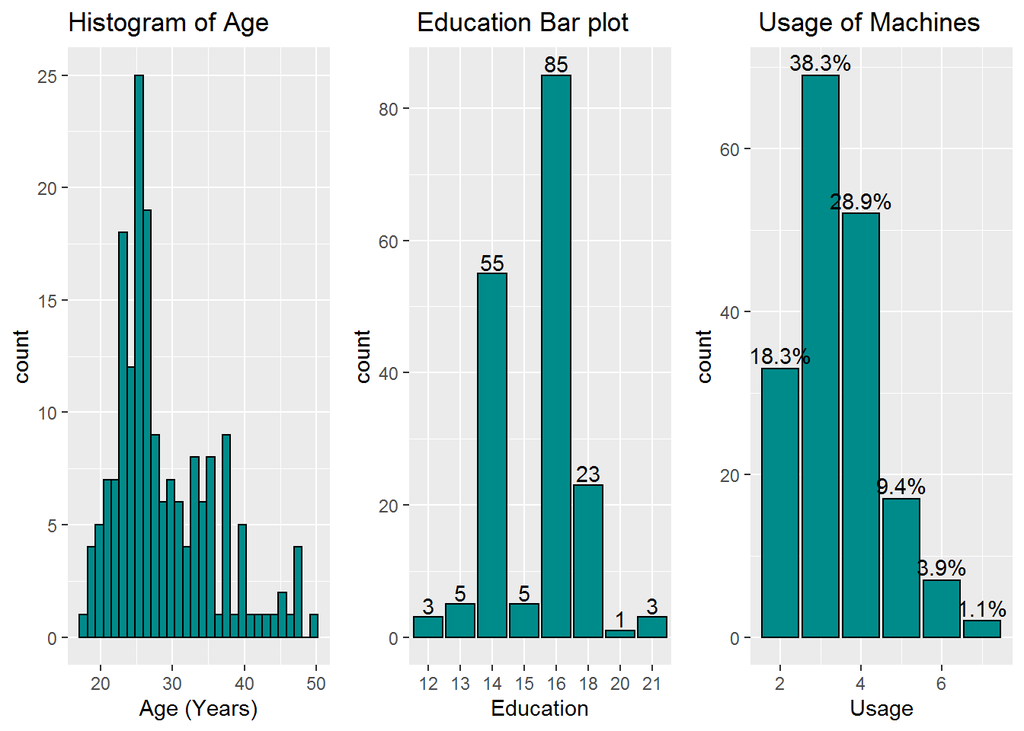

```r
#usage plot
p3<-ggplot(data = cardio_data, aes(x = Usage)) +
  geom_bar(color="black" ,fill="darkcyan") +
  theme_grey() + ggtitle(" Usage of Machines ")+
  geom_text(stat = 'count',aes(label =percent(round(..count../length(cardio_data$Usage),4)), vjust = -0.3))
#combining the plots
grid.arrange(p1,p2,p3,ncol=3)
```

if we saw the summary of the age, mean is slightly higher then the median and the distrubtion of the age is right skwed.if we find the coefficient of variation we only have 24%. its tell us sample age is not equally distributed. 2nd towards education plot its tell us the data sample people mostly are the 16 years of education it has 85 counts. 3rd usage of treadmill mostly user use the traedmill 38% of the people using the treadmill three times a week 29% of the people using 4 times a week.18% using only two times.

#### Gender summary and plot

```r
#Statisticl Summary of Gender
summary(cardio_data$Gender)
```

```
## Female   Male
##     76    104
```

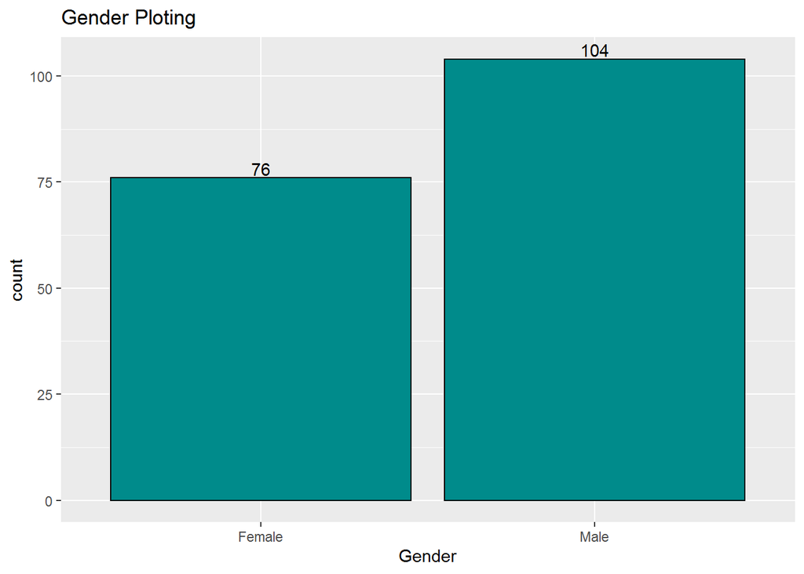

```r
ggplot(data = cardio_data, aes(x = Gender)) +
  geom_bar(color="black" ,fill="darkcyan") +
  theme_grey() + ggtitle("Gender Ploting")+
  geom_text(stat = 'count',aes(label =..count.., vjust = -0.2))
```

in this ploting the no of male users are 104 and female users are 76.

####Marital status and income summary and plot

```r
#Statisticl Summary of Marital Status
summary(cardio_data$MaritalStatus)
```

```
## Partnered    Single
##       107        73
```

```r
#Maritel status plot
p1<- ggplot(data = cardio_data, aes(x = MaritalStatus)) +
  geom_bar( color="black" ,fill="darkcyan") +
  theme_grey() + ggtitle("User Marital Status")+
  geom_text(stat = 'count',aes(label =..count.., vjust = -0.2))
#Statisticl Summary of income
summary(cardio_data$Income)
```

```
##    Min. 1st Qu.  Median    Mean 3rd Qu.    Max.
##   29562   44059   50597   53720   58668  104581
```

```r
sd(cardio_data$Income)
```

```
## [1] 16506.68
```

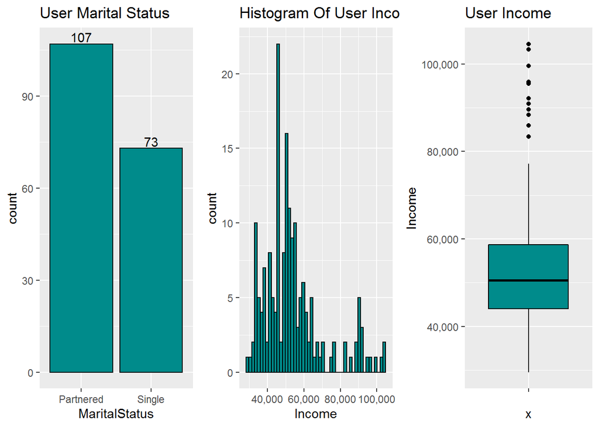

```r
#Income plot
p2<- ggplot(data = cardio_data, aes(x = Income)) +
  geom_histogram(bins = 50, color="black" ,fill="darkcyan") +
  theme_grey() + scale_x_continuous(labels = scales::comma) + ggtitle("Histogram Of User Income")


p3<- ggplot(data = cardio_data, aes(x = "",y=Income)) +
  geom_boxplot(color="black" ,fill="darkcyan") +
  theme_grey() +  ggtitle("User Income")+ scale_y_continuous(labels = scales::comma)
#combining the plots
grid.arrange(p1,p2,p3,ncol=3)
```

107 member has a partenered and 73 persons are single.user income has right skwed distribution because the mean is greater then median and coefficient of variation is 30%.

### 3.4 bivariate Analysis

```r
#statistical summary of Age and Gender
tapply(cardio_data$Age,cardio_data$Gender,summary)
```

```
## $Female
##    Min. 1st Qu.  Median    Mean 3rd Qu.    Max.
##   19.00   24.00   26.50   28.57   33.00   50.00
##
## $Male
##    Min. 1st Qu.  Median    Mean 3rd Qu.    Max.
##   18.00   23.75   26.00   28.95   34.00   48.00
```

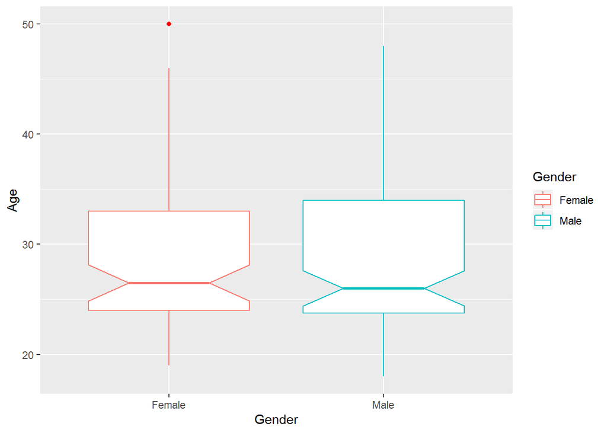

```r
ggplot(cardio_data,aes(x= Gender,y=Age)) +geom_boxplot(aes(colour = Gender), outlier.colour = "red",notch=TRUE)
```

this is biveriable / mean two veriable are used to show there relation between them as per the statistical summary of the plot. its between gender vs age. we find out female minimum age we have in this dataset is 19 and maximum is 50 as compare to female male has minimum 18 and maximum 48.male data is more right skwed then female data.this visualization telling us we have one outlier in female category age 50year is beyound the Q3+1.5IQR so we concider it outlier.

####Age vs Product summary and plot

```r
#statistical summary of Age and Product
tapply(cardio_data$Age,cardio_data$Product,summary)
```

```
## $TM195
##    Min. 1st Qu.  Median    Mean 3rd Qu.    Max.
##   18.00   23.00   26.00   28.55   33.00   50.00
##
## $TM498
##    Min. 1st Qu.  Median    Mean 3rd Qu.    Max.
##   19.00   24.00   26.00   28.90   33.25   48.00
##
## $TM798
##    Min. 1st Qu.  Median    Mean 3rd Qu.    Max.
##   22.00   24.75   27.00   29.10   30.25   48.00
```

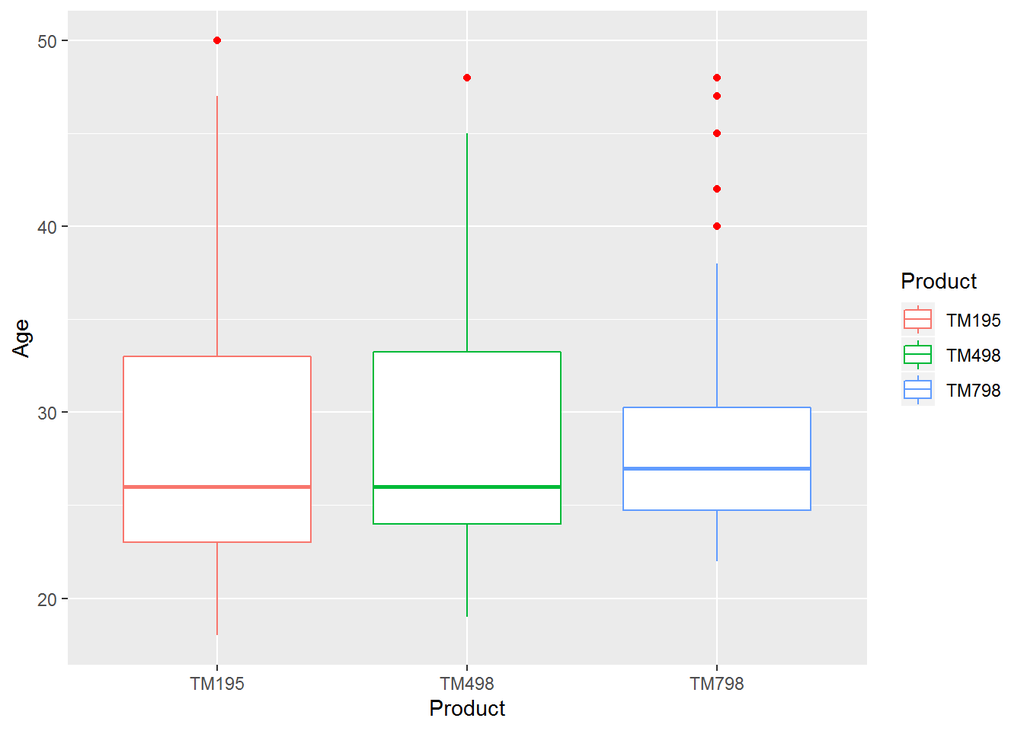

```r
ggplot(cardio_data,aes(x= Product,y=Age)) +geom_boxplot(aes(colour = Product), outlier.colour = "red",notch=FALSE)
```

In this figure we plot TM type and the user age. so here we will try to find out what is the age group of people or how many people using each paticular machine. As we see the statistical summary and graphical plot TM195 is most popular TM type among user then Tm 498 then TM798 respectively. as we see Tm 195 users are min 18 to 46 year old, TM498 showing almost same resemblance but TM798 is only popular 22 to 37 years old people using it. we also facing some outlier in this plot but most of the outlier belong to TM798.

#### Gender vs Fitness summary and plot

```r
#statistical summary of Age and Gender
cardio_data$age_group <- cut(cardio_data$Age, breaks = c(0, 25, 35, 50),
                             labels = c("less then 25","25 to 35","greater then 35"))
tapply(cardio_data$Fitness,cardio_data$age_group,summary)
```

```
## $`less then 25`
##    Min. 1st Qu.  Median    Mean 3rd Qu.    Max.
##   1.000   3.000   3.000   3.266   4.000   5.000
##
## $`25 to 35`
##    Min. 1st Qu.  Median    Mean 3rd Qu.    Max.
##   1.000   3.000   3.000   3.329   4.000   5.000
##
## $`greater then 35`
##    Min. 1st Qu.  Median    Mean 3rd Qu.    Max.
##   2.000   3.000   3.000   3.393   4.000   5.000
```

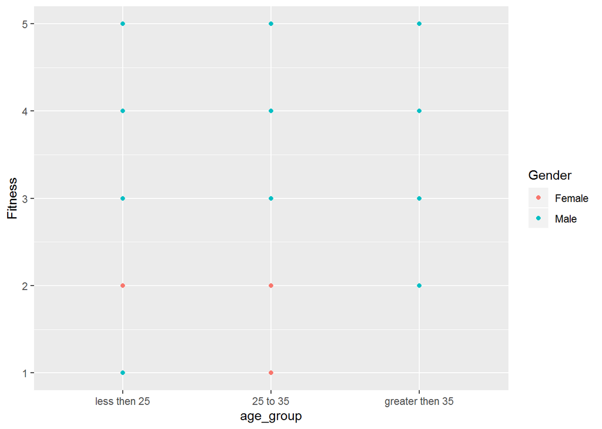

```r
  ggplot(cardio_data,aes(x= age_group,y=Fitness)) +geom_point(aes(col=Gender))
```

#### TM type vs User Income summary and plot

```r
#statistical summary of income and product
tapply(cardio_data$Income,cardio_data$Product,summary)
```

```
## $TM195
##    Min. 1st Qu.  Median    Mean 3rd Qu.    Max.
##   29562   38658   46617   46418   53439   68220
##
## $TM498
##    Min. 1st Qu.  Median    Mean 3rd Qu.    Max.
##   31836   44912   49460   48974   53439   67083
##
## $TM798
##    Min. 1st Qu.  Median    Mean 3rd Qu.    Max.
##   48556   58205   76569   75442   90886  104581
```

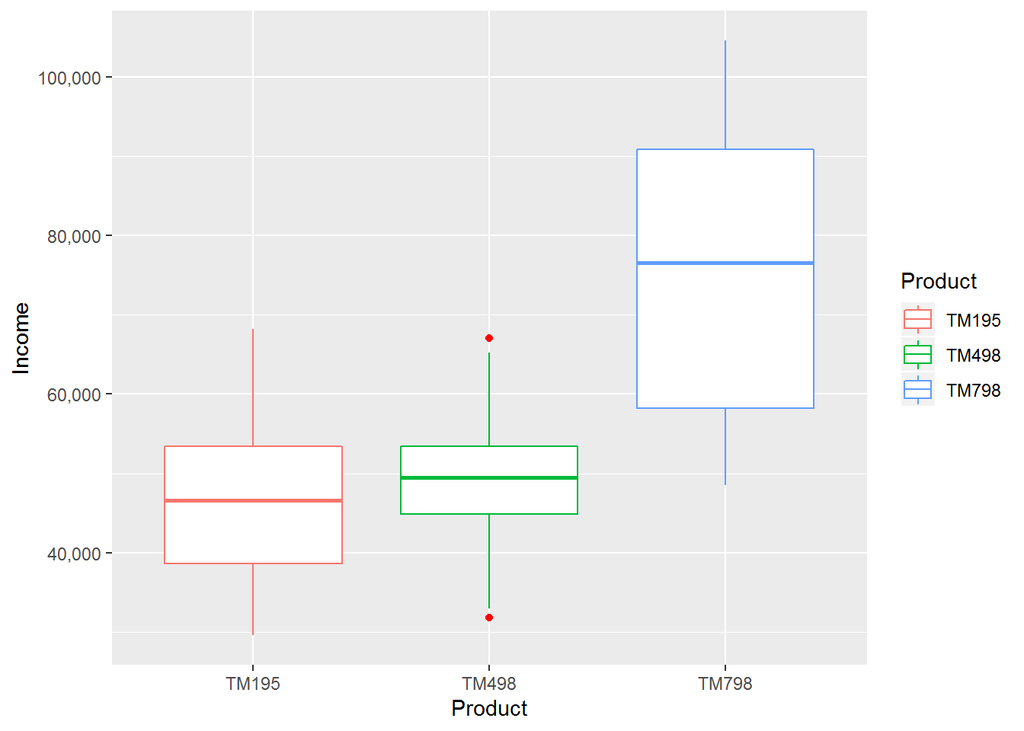

```r
ggplot(cardio_data,aes(x= Product,y=Income)) +geom_boxplot(aes(colour = Product), outlier.colour = "red",notch=FALSE) + scale_y_continuous(labels = scales::comma)
```

In this plot we find out TM798 only hit the high income customer its client has minimum 48 thousend and toward 1oo plus thousend. TM195 client has low salary as compared to other minimum 29 thousend to 68 thousend.

#### Product vs Usage summary and plot

```r
#statistical summary of usage and product
tapply(cardio_data$Usage,cardio_data$Product,summary)
```

```
## $TM195
##    Min. 1st Qu.  Median    Mean 3rd Qu.    Max.
##   2.000   3.000   3.000   3.087   4.000   5.000
##
## $TM498
##    Min. 1st Qu.  Median    Mean 3rd Qu.    Max.
##   2.000   3.000   3.000   3.067   3.250   5.000
##
## $TM798
##    Min. 1st Qu.  Median    Mean 3rd Qu.    Max.
##   3.000   4.000   5.000   4.775   5.000   7.000
```

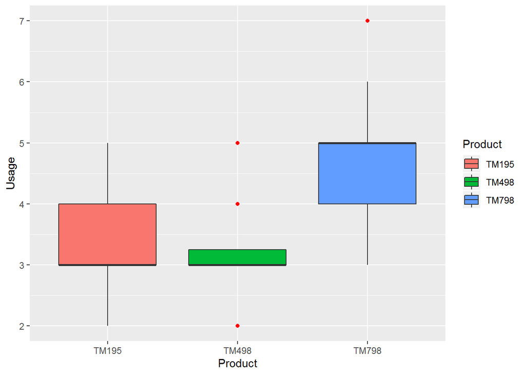

```r
ggplot(cardio_data,aes(x= Product,y=Usage)) +geom_boxplot(aes(fill = Product), outlier.colour = "red",notch=FALSE) + scale_y_continuous(labels = scales::comma)
```

in this plot we analyse TM798 usage is higher the other two products and secound most using by the customer is TM195.

#### Usage vs Income summary and plot

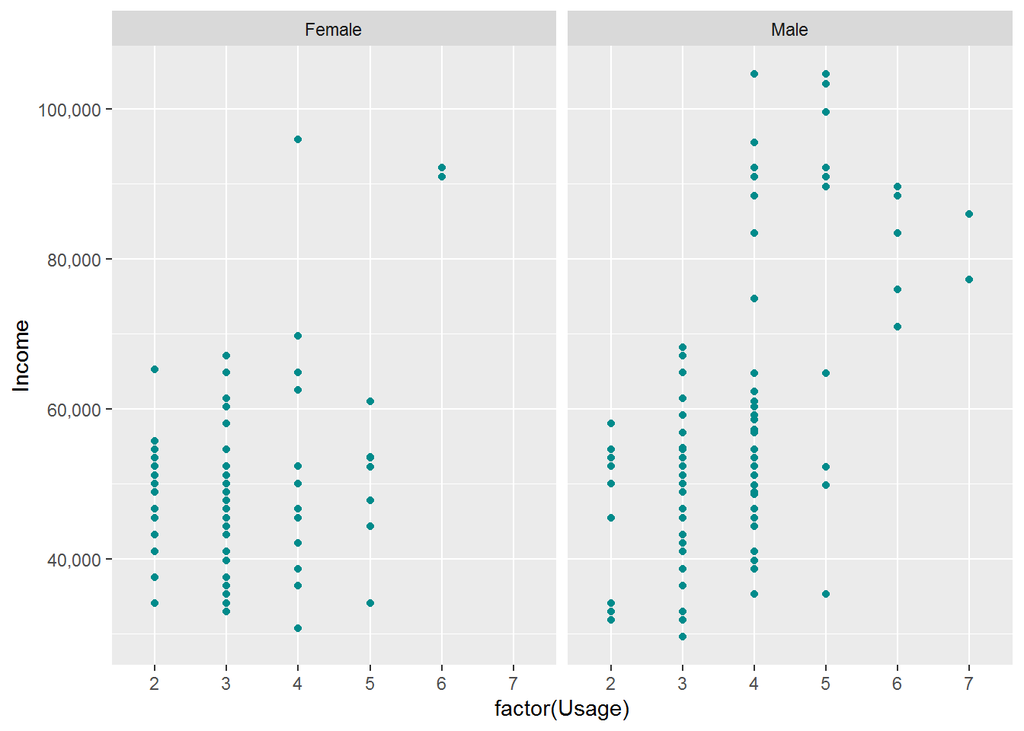

```r
#statistical summary of usge and income
ggplot(cardio_data,aes(x=factor(Usage) ,y=Income)) +
  geom_point(col="darkcyan")+
  geom_smooth(method = "lm", se = FALSE)+
  scale_y_continuous(labels =scales::comma)+
  facet_wrap(~ Gender)
```

In this we analyse usage of the treadmill and the customer income has relation between then we saw when ever the income increase the usage of the product also increase.

```r
tapply(cardio_data$Fitness,cardio_data$Product,summary)
```

```
## $TM195
##    Min. 1st Qu.  Median    Mean 3rd Qu.    Max.
##   1.000   3.000   3.000   2.962   3.000   5.000
##
## $TM498
##    Min. 1st Qu.  Median    Mean 3rd Qu.    Max.
##     1.0     3.0     3.0     2.9     3.0     4.0
##
## $TM798
##    Min. 1st Qu.  Median    Mean 3rd Qu.    Max.
##   3.000   4.000   5.000   4.625   5.000   5.000
```

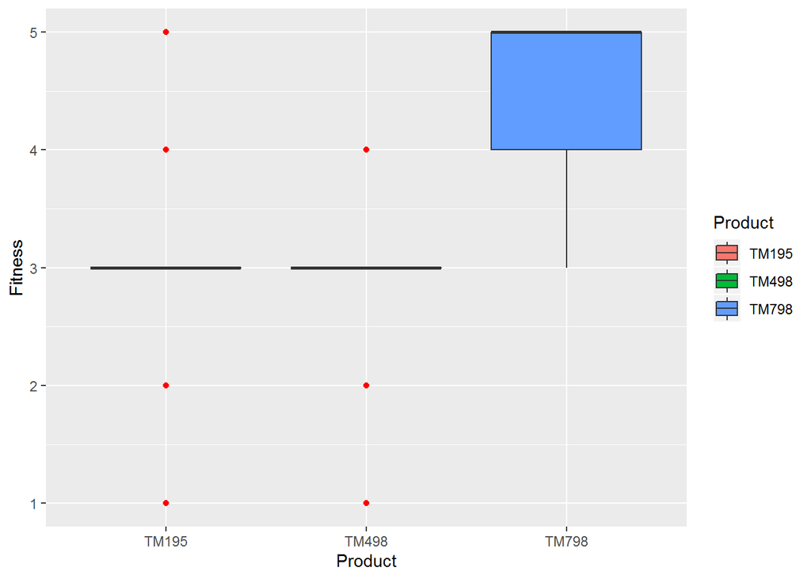

```r
ggplot(cardio_data,aes(x= Product,y=Fitness)) +geom_boxplot(aes(fill = Product), outlier.colour = "red",notch=FALSE) + scale_y_continuous(labels = scales::comma)
```

#### correlation Plot

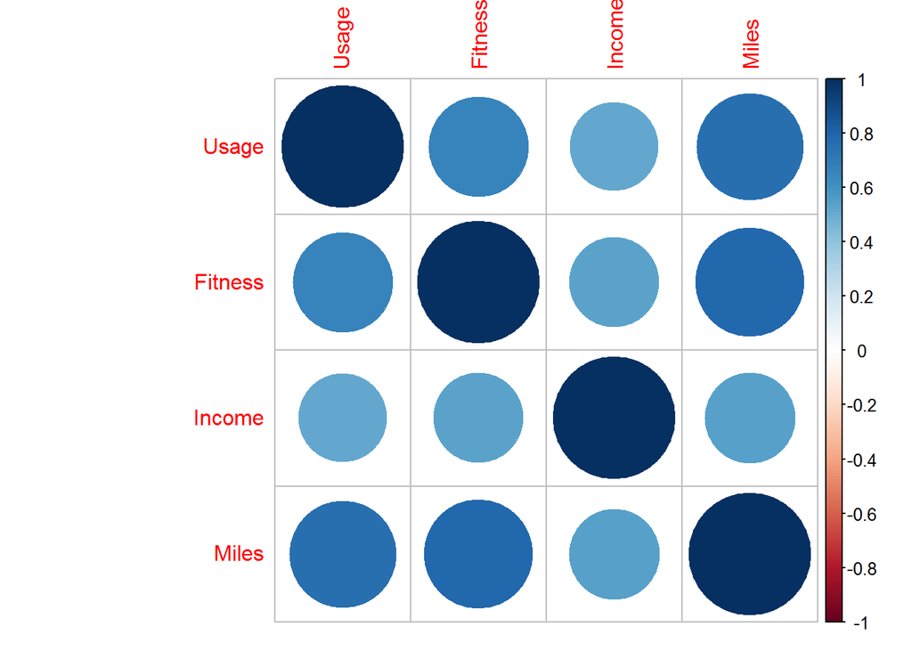

```r
corrplot(cor(cardio_data[,6:9]))
```

we draw correlation graph amoung numeric veriables and we find out great positive correlation amoung all of them.

#### Fitness Vs Miles summary and plot

```r
#statistical summary of miles and fitness
z <- lm(Fitness ~ Miles, data = cardio_data)
coef(z)
```

```
## (Intercept)       Miles
##  1.81208079  0.01452627
```

```r
tapply(cardio_data$Miles,cardio_data$Fitness,summary)
```

```
## $`1`
##    Min. 1st Qu.  Median    Mean 3rd Qu.    Max.
##    21.0    27.5    34.0    34.0    40.5    47.0
##
## $`2`
##    Min. 1st Qu.  Median    Mean 3rd Qu.    Max.
##   38.00   43.25   47.00   51.69   53.00   85.00
##
## $`3`
##    Min. 1st Qu.  Median    Mean 3rd Qu.    Max.
##   53.00   75.00   85.00   87.19   95.00  170.00
##
## $`4`
##    Min. 1st Qu.  Median    Mean 3rd Qu.    Max.
##    74.0   106.0   127.0   131.6   160.0   212.0
##
## $`5`
##    Min. 1st Qu.  Median    Mean 3rd Qu.    Max.
##    80.0   150.0   170.0   178.9   200.0   360.0
```

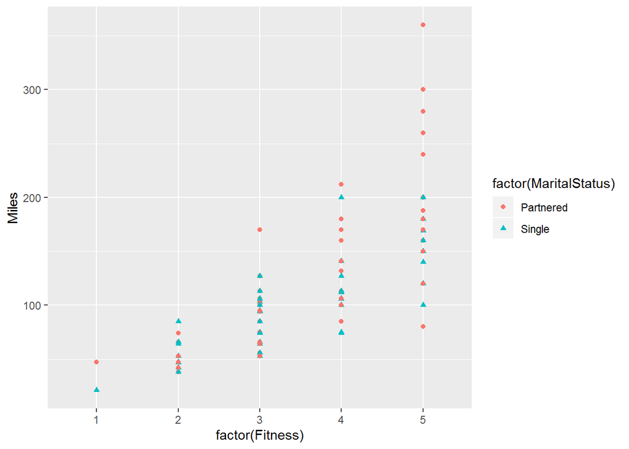

```r
ggplot(cardio_data,aes(x=factor(Fitness),y=Miles)) +
  geom_point(aes(shape=factor(MaritalStatus),col=factor(MaritalStatus)))+
  geom_smooth(method = "lm", se = FALSE)
```

```r
  #geom_abline(intercept = 1.81, slope = 0.01)
```

#### Fitness vs usage

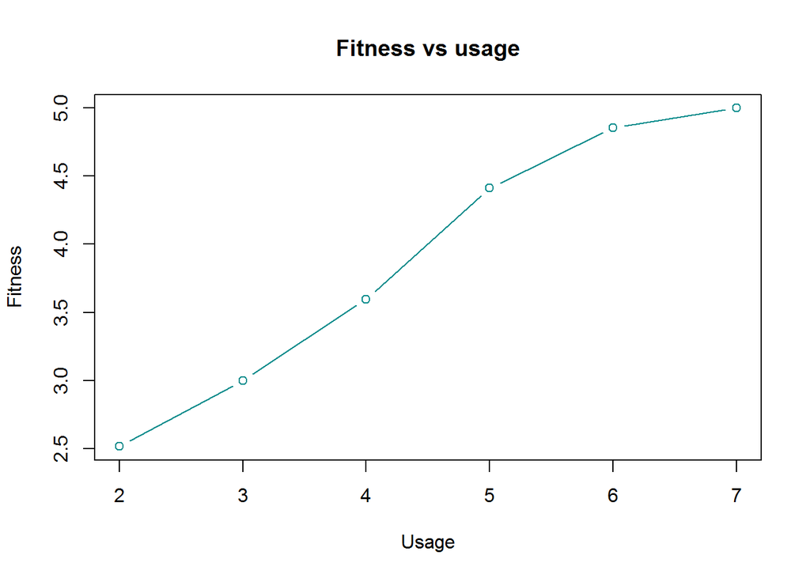

```r
plot(aggregate(Fitness~Usage,data= cardio_data,mean),type = "b",main="Fitness vs usage",col="darkcyan")
```

we noticed fitness and usage has positive correlation.

#### Age vs Income plot

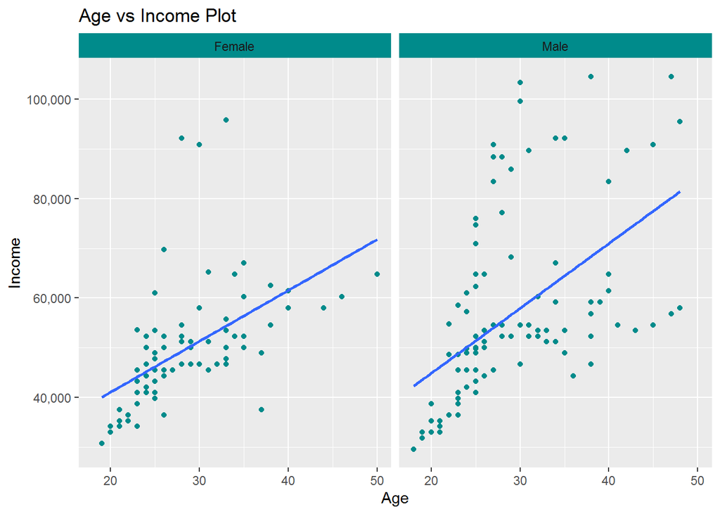

```r
ggplot(cardio_data,aes(x=Age ,y=Income)) +
  geom_point(col="darkcyan")+
  scale_y_continuous(labels =scales::comma)+
  facet_wrap(~ Gender)+
  geom_smooth(method = "lm", se = FALSE)+
  theme(strip.background = element_rect(fill=c("darkcyan")))+
  ggtitle("Age vs Income Plot ")
```

we saw some positive correlation between age and income with repect to gender. we also find out the slope of the line in male panel is higher then female panel its mean male age and income has more stronger correlation between them as respect to female.

#### Education vs Income Plot

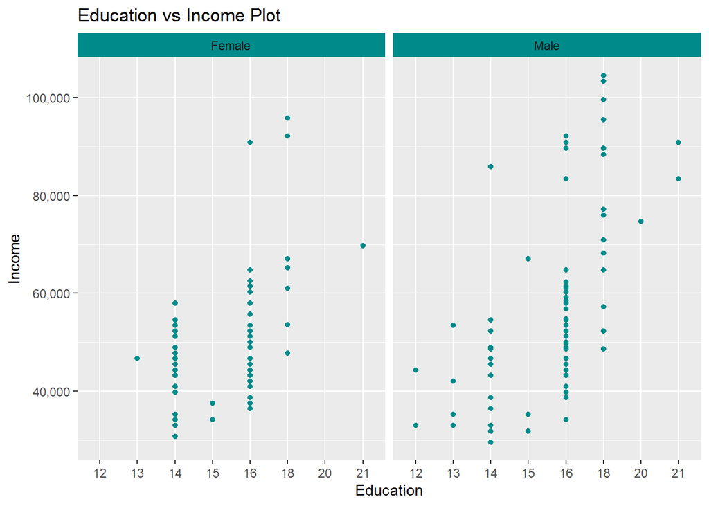

```r
ggplot(cardio_data,aes(x=Education ,y=Income)) +
  geom_point(col="darkcyan")+
  scale_y_continuous(labels =scales::comma)+
  facet_wrap(~ Gender)+
  geom_smooth(method = "lm", se = FALSE)+
  theme(strip.background = element_rect(fill=c("darkcyan")))+
  ggtitle("Education vs Income Plot ")
```

#### AGE Vs Miles

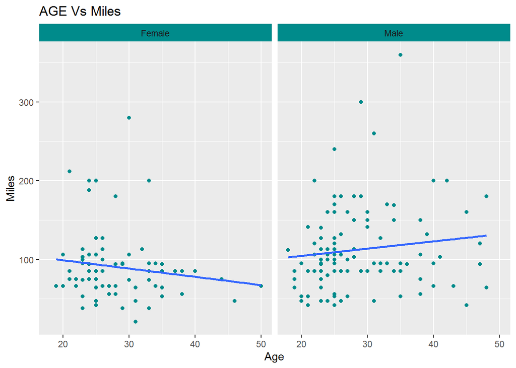

```r
ggplot(cardio_data,aes(x=Age ,y=Miles)) +
  geom_point(col="darkcyan")+
  scale_y_continuous(labels =scales::comma)+
  facet_wrap(~ Gender)+
  geom_smooth(method = "lm", se = FALSE)+
  theme(strip.background = element_rect(fill=c("darkcyan")))+
  ggtitle("AGE Vs Miles")
```

here we saw some interesting ehaviour male has positive coorrelationbetween age and miles its mean male customers are covering miles increase with respect to age. But female has negative correlation between age and miles covering.

### Conclusion

for the company interest when the company design the new product company has to take attention on female users because female users health condiction is worst then male users. upon the this interest we have to design the product where female users build an interest init and also concider the female users income codition.

##*************THE END *************